# Assignment1: Liquified Petroleum Gas

Abha Sharma

2024-03-04

## Introduction :

Data Source:  
The dataset utilized for this analysis is sourced from the United Nations Statistics Division. It offers insights into the consumption of Liquefied Petroleum Gas (LPG) by households across multiple countries, spanning from year 1990 onwards.

Dataset URL: The dataset can be accessed at [url](https://data.un.org/Data.aspx?d=EDATA&f=cmID%3aLP%3btrID%3a1231)

Variables :  
Country or Area : Categorical variable indicating the country name.  
Commodity…Transaction : Categorical variable indicating the mode of LPG consumption.  
Year : Numerical variable representing the year of consumption data.  
Unit : Represents the units of measurement of data in thousands of metric tons. A character variable.  
Quantity : Numerical variable representing the amount of LPG consumed by a particular country.

## Loading csv data into R :

```r
df = read.csv("Assignment1households-Sharma.csv")

glimpse(df)
```

```
## Rows: 5,951
## Columns: 5
## $ Country.or.Area         <chr> "Afghanistan", "Afghanistan", "Afghanistan", "…
## $ Commodity...Transaction <chr> "Liquefied petroleum gas (LPG) - Consumption b…
## $ Year                    <int> 2022, 2021, 2020, 2019, 2018, 2017, 2016, 2015…
## $ Unit                    <chr> "Metric tons,  thousand", "Metric tons,  thous…
## $ Quantity                <dbl> 580.0, 595.0, 656.4, 652.1, 593.3, 605.9, 715.…
```

```r
summary(df)
```

```
##  Country.or.Area    Commodity...Transaction      Year          Unit
##  Length:5951        Length:5951             Min.   :1990   Length:5951
##  Class :character   Class :character        1st Qu.:1999   Class :character
##  Mode  :character   Mode  :character        Median :2007   Mode  :character
##                                             Mean   :2006
##                                             3rd Qu.:2014
##                                             Max.   :2022
##     Quantity
##  Min.   :    0.00
##  1st Qu.:    4.91
##  Median :   25.00
##  Mean   :  480.80
##  3rd Qu.:  224.50
##  Max.   :32250.30
```

```r
duplicate_indices <- which(duplicated(df))
duplicate_indices
```

```
## integer(0)
```

## Tidy or Untidy ?

```r
colnames(df)
```

```
## [1] "Country.or.Area"         "Commodity...Transaction"
## [3] "Year"                    "Unit"
## [5] "Quantity"
```

```r
unique(df$Unit)
```

```
## [1] "Metric tons,  thousand"
```

```r
df <- rename(df, Country = Country.or.Area, Transaction = Commodity...Transaction)

kable(head(df, n = 10)) |> kable_styling()
```

| Country | Transaction | Year | Unit | Quantity |
| --- | --- | --- | --- | --- |
| Afghanistan | Liquefied petroleum gas (LPG) - Consumption by households | 2022 | Metric tons, thousand | 580.0 |
| Afghanistan | Liquefied petroleum gas (LPG) - Consumption by households | 2021 | Metric tons, thousand | 595.0 |
| Afghanistan | Liquefied petroleum gas (LPG) - Consumption by households | 2020 | Metric tons, thousand | 656.4 |
| Afghanistan | Liquefied petroleum gas (LPG) - Consumption by households | 2019 | Metric tons, thousand | 652.1 |
| Afghanistan | Liquefied petroleum gas (LPG) - Consumption by households | 2018 | Metric tons, thousand | 593.3 |
| Afghanistan | Liquefied petroleum gas (LPG) - Consumption by households | 2017 | Metric tons, thousand | 605.9 |
| Afghanistan | Liquefied petroleum gas (LPG) - Consumption by households | 2016 | Metric tons, thousand | 715.8 |
| Afghanistan | Liquefied petroleum gas (LPG) - Consumption by households | 2015 | Metric tons, thousand | 686.0 |
| Afghanistan | Liquefied petroleum gas (LPG) - Consumption by households | 2014 | Metric tons, thousand | 458.6 |
| Afghanistan | Liquefied petroleum gas (LPG) - Consumption by households | 2013 | Metric tons, thousand | 348.4 |

From the above dataset we can see that each variable is represented by a column. Each row in the dataset represents an unique observation or instance. Each value is stored in a separate cell. Therefore, this is a tidy dataset.

## Converting the above tidy dataset into untidy data :

```r
untidy_df <- pivot_wider(df, names_from = Year, values_from = Quantity)
kable(head(untidy_df, n = 10)) |> kable_styling()
```

| Country | Transaction | Unit | 2022 | 2021 | 2020 | 2019 | 2018 | 2017 | 2016 | 2015 | 2014 | 2013 | 2012 | 2011 | 2010 | 2009 | 2008 | 2007 | 2006 | 2005 | 2004 | 2003 | 2002 | 2001 | 2000 | 1999 | 1998 | 1997 | 1996 | … |
| --- | --- | --- | --- | --- | --- | --- | --- | --- | --- | --- | --- | --- | --- | --- | --- | --- | --- | --- | --- | --- | --- | --- | --- | --- | --- | --- | --- | --- | --- | --- |
| Afghanistan | Liquefied petroleum gas (LPG) - Consumption by households | Metric tons, thousand | 580.000 | 595.000 | 656.4000 | 652.100 | 593.300 | 605.900 | 715.8 | 686.00 | 458.60 | 348.40 | 206.30 | 198.30 | 103.1 | 64.50 | 41.70 | 47.00 | 46.00 | 51.00 | 47.00 | 50.00 | 49.00 | 48.00 | 47.00 | 45.00 | 43.00 | 42.00 | 41.00 | … |
| Albania | Liquefied petroleum gas (LPG) - Consumption by households | Metric tons, thousand | 101.120 | 108.120 | 100.1200 | 97.000 | 97.000 | 95.000 | 85.0 | 81.00 | 79.23 | 73.73 | 70.00 | 70.00 | 80.0 | 69.75 | 63.00 | 53.00 | 57.00 | 9.00 | 37.00 | 30.00 | 29.00 | 23.00 | 21.00 | 19.00 | NA | NA | NA | … |
| Algeria | Liquefied petroleum gas (LPG) - Consumption by households | Metric tons, thousand | NA | 1261.000 | 1332.0000 | 1411.000 | 1417.000 | 1414.000 | 1428.0 | 1494.00 | 1457.00 | 1530.00 | 1566.00 | 1485.00 | 1472.0 | 1481.00 | 1272.00 | 1299.00 | 1302.00 | 1450.00 | 1597.00 | 1359.00 | 1372.00 | 1353.00 | 1443.00 | 1441.00 | 1398.00 | 1322.00 | 1337.00 | … |
| American Samoa | Liquefied petroleum gas (LPG) - Consumption by households | Metric tons, thousand | NA | NA | NA | NA | NA | NA | NA | NA | NA | NA | NA | NA | 1.6 | 1.60 | 1.60 | 1.60 | 1.60 | 1.00 | 1.00 | 1.00 | 1.00 | 1.00 | 1.00 | 1.00 | 1.00 | 1.00 | 1.00 | … |
| Andorra | Liquefied petroleum gas (LPG) - Consumption by households | Metric tons, thousand | 2.090 | 1.980 | 1.8900 | 2.338 | 2.360 | 2.240 | 2.2 | 2.18 | 2.16 | 2.19 | 2.34 | 2.59 | 2.7 | 2.61 | 2.85 | 2.90 | 2.92 | 3.25 | 3.28 | 3.02 | 3.35 | 2.90 | 2.96 | 2.99 | 2.70 | 2.57 | 2.63 | … |
| Angola | Liquefied petroleum gas (LPG) - Consumption by households | Metric tons, thousand | 449.200 | 411.791 | 402.9920 | 269.200 | 332.985 | 304.000 | 221.0 | 234.00 | 212.00 | 250.00 | 239.00 | 142.00 | 135.0 | 154.00 | 131.00 | 111.00 | 88.00 | 86.00 | 73.00 | 77.00 | 71.00 | 58.00 | 44.00 | 42.00 | 46.00 | 46.00 | 48.00 | … |
| Anguilla | Liquefied petroleum gas (LPG) - Consumption by households | Metric tons, thousand | 8.500 | 8.300 | 8.1000 | 8.800 | 8.700 | 8.600 | 9.1 | 9.10 | 5.70 | 5.20 | 5.50 | 5.30 | 5.4 | 5.00 | 4.70 | 4.50 | 4.00 | 3.60 | 4.20 | 3.70 | 3.90 | 4.40 | 4.20 | 4.10 | 4.00 | 3.90 | 3.70 | … |
| Antigua and Barbuda | Liquefied petroleum gas (LPG) - Consumption by households | Metric tons, thousand | 3.700 | 3.600 | 3.6000 | 3.700 | 3.700 | 3.600 | 3.6 | 3.50 | 3.40 | 3.30 | 3.30 | 3.20 | 3.0 | 3.30 | 3.10 | 3.00 | 3.00 | 2.00 | 2.00 | 2.00 | 2.00 | 2.00 | 2.00 | 2.00 | 2.00 | 2.00 | 2.00 | … |
| Argentina | Liquefied petroleum gas (LPG) - Consumption by households | Metric tons, thousand | 1258.868 | 1193.881 | 948.5146 | 1083.000 | 1096.000 | 1166.000 | 1242.0 | 1225.00 | 1236.00 | 1294.00 | 803.00 | 704.00 | 1168.0 | 1063.00 | 1085.00 | 825.00 | 1448.00 | 866.00 | 898.00 | 795.00 | 623.00 | 961.00 | 1010.00 | 939.00 | 913.00 | 805.00 | 804.00 | … |
| Armenia | Liquefied petroleum gas (LPG) - Consumption by households | Metric tons, thousand | NA | 0.343 | 0.1690 | 0.355 | 0.796 | 0.298 | 0.2 | 0.30 | 0.29 | 0.32 | 0.30 | 0.32 | 0.3 | 0.33 | 0.39 | 0.49 | 0.65 | 0.87 | 0.04 | 0.04 | 0.04 | 0.04 | 0.04 | 0.04 | 0.04 | 0.04 | 0.04 | … |

The above dataset is now untidy as the value of column “Year” is now spread across the dataset. A vector of column names that contain values, not variables. This violates one of the tidy data principles which states that each variable should have a column.

## Converting the untidy dataset back to tidy dataset :

```r
tidy_df <- untidy_df |>  pivot_longer(`1990`:`2022`, names_to = "Year", values_to ="Quantity" , values_drop_na = TRUE)

kable(head(tidy_df, n = 10)) |> kable_styling()
```

| Country | Transaction | Unit | Year | Quantity |
| --- | --- | --- | --- | --- |
| Afghanistan | Liquefied petroleum gas (LPG) - Consumption by households | Metric tons, thousand | 1990 | 31 |
| Afghanistan | Liquefied petroleum gas (LPG) - Consumption by households | Metric tons, thousand | 1991 | 33 |
| Afghanistan | Liquefied petroleum gas (LPG) - Consumption by households | Metric tons, thousand | 1992 | 34 |
| Afghanistan | Liquefied petroleum gas (LPG) - Consumption by households | Metric tons, thousand | 1993 | 36 |
| Afghanistan | Liquefied petroleum gas (LPG) - Consumption by households | Metric tons, thousand | 1994 | 38 |
| Afghanistan | Liquefied petroleum gas (LPG) - Consumption by households | Metric tons, thousand | 1995 | 39 |
| Afghanistan | Liquefied petroleum gas (LPG) - Consumption by households | Metric tons, thousand | 1996 | 41 |
| Afghanistan | Liquefied petroleum gas (LPG) - Consumption by households | Metric tons, thousand | 1997 | 42 |
| Afghanistan | Liquefied petroleum gas (LPG) - Consumption by households | Metric tons, thousand | 1998 | 43 |
| Afghanistan | Liquefied petroleum gas (LPG) - Consumption by households | Metric tons, thousand | 1999 | 45 |

```r
tidy_df$Year <- as.integer(tidy_df$Year)

kable(head(tidy_df, n = 10)) |> kable_styling()
```

| Country | Transaction | Unit | Year | Quantity |
| --- | --- | --- | --- | --- |
| Afghanistan | Liquefied petroleum gas (LPG) - Consumption by households | Metric tons, thousand | 1990 | 31 |
| Afghanistan | Liquefied petroleum gas (LPG) - Consumption by households | Metric tons, thousand | 1991 | 33 |
| Afghanistan | Liquefied petroleum gas (LPG) - Consumption by households | Metric tons, thousand | 1992 | 34 |
| Afghanistan | Liquefied petroleum gas (LPG) - Consumption by households | Metric tons, thousand | 1993 | 36 |
| Afghanistan | Liquefied petroleum gas (LPG) - Consumption by households | Metric tons, thousand | 1994 | 38 |
| Afghanistan | Liquefied petroleum gas (LPG) - Consumption by households | Metric tons, thousand | 1995 | 39 |
| Afghanistan | Liquefied petroleum gas (LPG) - Consumption by households | Metric tons, thousand | 1996 | 41 |
| Afghanistan | Liquefied petroleum gas (LPG) - Consumption by households | Metric tons, thousand | 1997 | 42 |
| Afghanistan | Liquefied petroleum gas (LPG) - Consumption by households | Metric tons, thousand | 1998 | 43 |
| Afghanistan | Liquefied petroleum gas (LPG) - Consumption by households | Metric tons, thousand | 1999 | 45 |

The untidy data is now converted back to tidy format. Here, the vector of column names such as 1990, 1991 etc. are combined into one variable i.e. Year, thereby satisfying all tidy data principles. This is a tidy dataset.

## Creating plots :

```r
knitr::opts_chunk$set(echo = TRUE)

library(dplyr)
library(ggplot2)

# Define the range of years for each facet

first_df <- tidy_df |>
  mutate(Year_range = case_when(
    between(Year, 1990, 2000) ~ "1990-2000",
    between(Year, 2001, 2011) ~ "2001-2011",
    Year >= 2012  ~ "2012 onwards"
  ))

first_df$Year <- factor(first_df$Year)


kable(head(first_df, n = 10)) |> kable_styling()
```

| Country | Transaction | Unit | Year | Quantity | Year_range |
| --- | --- | --- | --- | --- | --- |
| Afghanistan | Liquefied petroleum gas (LPG) - Consumption by households | Metric tons, thousand | 1990 | 31 | 1990-2000 |
| Afghanistan | Liquefied petroleum gas (LPG) - Consumption by households | Metric tons, thousand | 1991 | 33 | 1990-2000 |
| Afghanistan | Liquefied petroleum gas (LPG) - Consumption by households | Metric tons, thousand | 1992 | 34 | 1990-2000 |
| Afghanistan | Liquefied petroleum gas (LPG) - Consumption by households | Metric tons, thousand | 1993 | 36 | 1990-2000 |
| Afghanistan | Liquefied petroleum gas (LPG) - Consumption by households | Metric tons, thousand | 1994 | 38 | 1990-2000 |
| Afghanistan | Liquefied petroleum gas (LPG) - Consumption by households | Metric tons, thousand | 1995 | 39 | 1990-2000 |
| Afghanistan | Liquefied petroleum gas (LPG) - Consumption by households | Metric tons, thousand | 1996 | 41 | 1990-2000 |
| Afghanistan | Liquefied petroleum gas (LPG) - Consumption by households | Metric tons, thousand | 1997 | 42 | 1990-2000 |
| Afghanistan | Liquefied petroleum gas (LPG) - Consumption by households | Metric tons, thousand | 1998 | 43 | 1990-2000 |
| Afghanistan | Liquefied petroleum gas (LPG) - Consumption by households | Metric tons, thousand | 1999 | 45 | 1990-2000 |

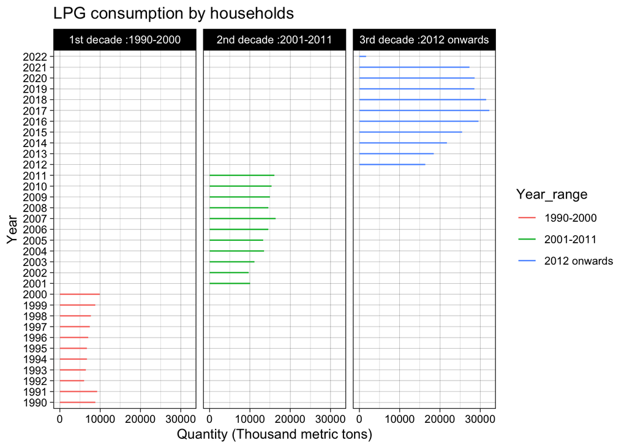

```r
# Plot with "Quantity" on the x-axis and "Year" on the y-axis
ggplot(data = first_df, mapping = aes(x=Quantity, y=Year)) +
  geom_line(aes(colour = Year_range)) +
  labs(title = "LPG consumption by households",
       x = "Quantity (Thousand metric tons)",
       y = "Year") +
  facet_wrap(~Year_range, ncol = 3,scales = "fixed",
             labeller = as_labeller(c("1990-2000" = "1st decade :1990-2000",
                                      "2001-2011" = "2nd decade :2001-2011",
                                      "2012 onwards" = "3rd decade :2012 onwards"))) +
  theme_linedraw()
```

```r
###Top country with the highest LPG consumption for each year

top_countries <- first_df |>
  select(Country, Year, Quantity) |>
  group_by( Year) |>
  arrange(desc(Quantity)) |>
  slice_head(n = 1)

top_countries |> kbl() |> kable_styling()
```

| Country | Year | Quantity |
| --- | --- | --- |
| USSR (former) | 1990 | 8800.00 |
| USSR (former) | 1991 | 9250.00 |
| Mexico | 1992 | 6015.00 |
| Mexico | 1993 | 6437.00 |
| Mexico | 1994 | 6716.00 |
| Mexico | 1995 | 6702.00 |
| China | 1996 | 7035.00 |
| China | 1997 | 7422.00 |
| China | 1998 | 7692.00 |
| China | 1999 | 8785.00 |
| China | 2000 | 9883.00 |
| China | 2001 | 10060.00 |
| China | 2002 | 9691.00 |
| China | 2003 | 11127.00 |
| China | 2004 | 13505.00 |
| China | 2005 | 13287.00 |
| China | 2006 | 14562.00 |
| China | 2007 | 16379.00 |
| China | 2008 | 14570.00 |
| China | 2009 | 14957.00 |
| China | 2010 | 15370.06 |
| China | 2011 | 16071.50 |
| China | 2012 | 16353.80 |
| China | 2013 | 18455.80 |
| China | 2014 | 21731.40 |
| China | 2015 | 25493.50 |
| China | 2016 | 29554.10 |
| China | 2017 | 32250.30 |
| China | 2018 | 31472.80 |
| China | 2019 | 28546.70 |
| China | 2020 | 28603.50 |
| China | 2021 | 27321.00 |
| Thailand | 2022 | 1665.90 |

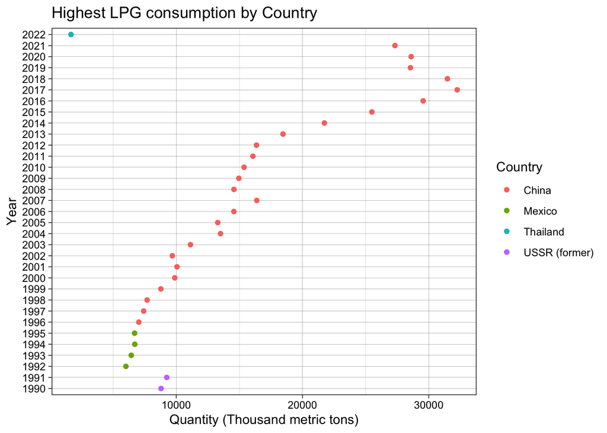

```r
ggplot(data = top_countries, mapping = aes(x = Quantity, y = Year)) +
  geom_point(aes(color = Country)) +
  labs(title = "Highest LPG consumption by Country",
       x = "Quantity (Thousand metric tons)",
       y = "Year") +
  theme_linedraw()
```

## Identifying patterns in each plot:

In the second decade (2001-2011), the peak LPG consumption was observed in the year 2007, totaling nearly 16,000 thousand metric tons.

Lastly, the year 2017 marked the recent peak in LPG consumption, exceeding 30,000 thousand metric tons. Among all reported time periods, the year 2017 recorded the highest-ever LPG consumption by households.

**Second plot:** This visualization depicts the country with the highest LPG consumption each year from 1990 to 2022. During the early years, from 1990 to 1995, the top contributors to LPG consumption were the USSR(former) and Mexico.

Subsequently, from 1996 to 2021, China consistently emerged as the leading consumer of LPG among households. Notably, in 2017, China reached the peak of its LPG consumption.